# 二項分布が生まれるまで

19/07/25

## 誰？

- [きぬいと](https://twitter.com/0_u0)
  - ダブルブッキングで本人不在プレゼンをかました
    - kur0cky先生ありがとう
- JTMRC所属
  - Japanese Traditional Marketing Research Company
- 主な仕事
  - Rコード1行ですべてを終わらせる
  - Excelでお客様のお気持ちに寄り添う
    - 寄り添い方を考えたい
- ゆるふわkaggleプレイヤー
  - kaggleではPython

## Statistician-ja

- 立てました
  - 20人くらいのつもりが今や200人超えてしまった
- 今日のお話もここの議論がベース
  - 現業に忙殺されてこっちの仕事ができていない
  - 仕事に追われる生活を脱したい

## 今日のお話

- 確率「分布」のお話
  - [我々は確率を知った](https://speakerdeck.com/kilometer/tokyo-dot-r-number-79-beginnersession-que-lu-falseji-chu)
- しかし我々は「正規分布」ってよくわからない

## 今日のお話

- 「統計」の根源
  - 数えて、記録して、集める。
- 我々はいろいろなものを数えてきた
- 記録したら、なにか法則性が見えてきた
- その法則性が「分布」……

確率分布はどこからきたのか

確率分布とは何者か

確率分布はどこへいくのか

## とはいえ

- 確率分布について全部話すとなると20分は厳しい。
  - 何か一つに絞るしかない
- 人生で必ず一回は目にするであろう統計屋の地図があります。

## 確率分布曼荼羅

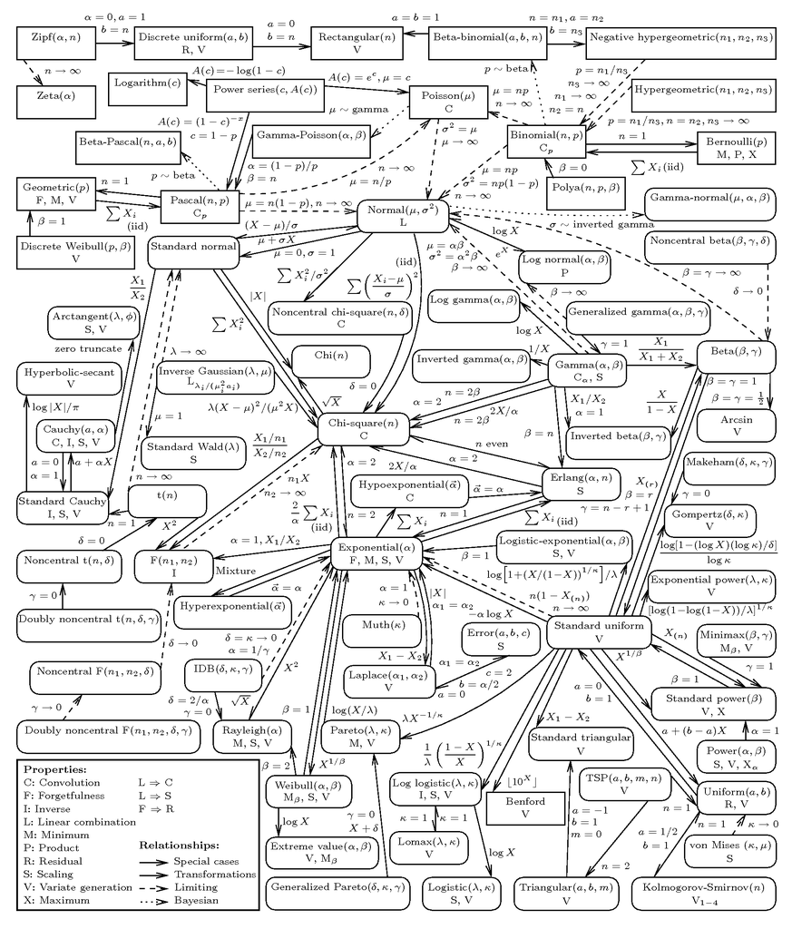

## 今回は

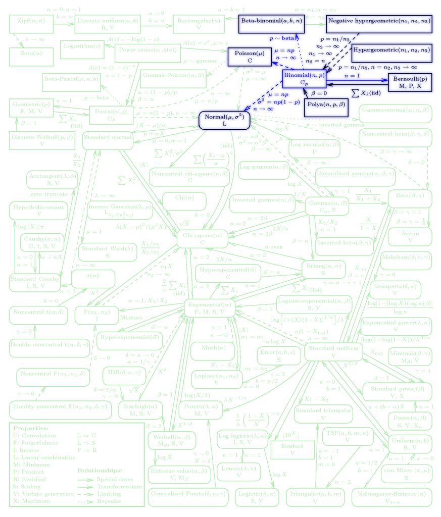

## 今回は→二項分布

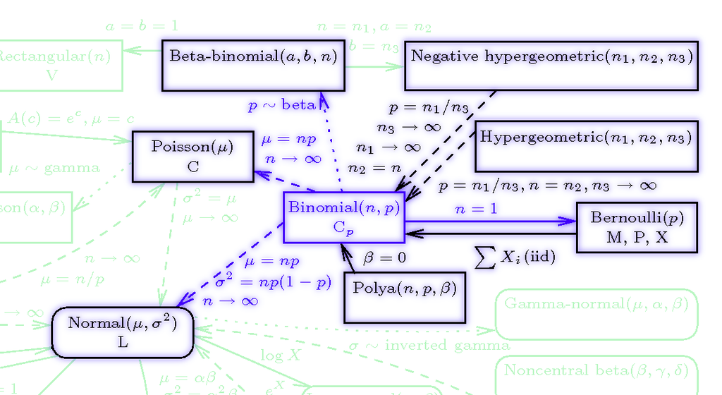

- by: http://www.math.wm.edu/~leemis/chart/UDR/UDR.html

## 今回は→二項分布

- [このサイトがすごい2019](http://www.math.wm.edu/~leemis/chart/UDR/UDR.html)
- いろんな確率分布の関係がにょろにょろしている
- 写経して心を清らかに保とう

## なぜ二項分布？

- 最も「古い」確率分布
  - 諸説あり
- 正規分布の親みたいなところがある
  - 正規分布の親の顔が見てみたい
- もっとも「単純」な確率分布(だと思ってる)
  - コイントス好き？アタシは好き。
  - 考えるべきことは\(p\)と\(n\)と\(k\)だけ
  - \(p\)以外離散パラメータ

## 対象者

- 確率分布わからない人
- 一か八かの賭けが好きな人(私は嫌いではない)
- """""“完全理解者”"""""の皆さんへ
  - 測度論は出てきません(公理化は最新技術なので)
  - ベイズなアイツもでてきません(頻度論アプローチ)
  - マサカリって「マサ」を「カる」んだろうけど「マサ」って何？

## 分布を考える前に……

- 統計学や確率論の入門書をみると
  - 分布の前に代表値の話に章を割く
- 言われてみれば代表値なんもわからんくないですか？
  - せめて平均だけでも持って返ってください
  - あとついでに分散も

## 平均

- 例)コイントスを100回したとき「表」は何回くらい出そうか？
  - マサカリバリア: 歪みのないコインです
  - マサカリバリア: コイントスしても歪みません
  - マサカリバリア: 独立試行です。コイントスは練習しても表を出しやすくできない世界。
- 直感を信じてみる
  - 「歪みのないコインでコイントスをしたら半分くらいは表になるんじゃね？」

## 平均とは

- 観測値の総和を試行回数で割る。
  - 今回は表が出る回数を問うているので、表が出たら1、裏なら0と記録する係を雇う
- きぬいと: 人望がないのでRに頼る
  - コイントス100回の試行を100回繰り返す。
  - すでに「分布」に頼ってしまっている(run-ifではなくr-unifなんだね)

```r
X <- numeric(100)
for(try in 1:100){
  set.seed(20+try) # seed値を毎回変える
  X[try] <- sum(round(runif(100, min = 0, max = 1)))
}
mean_X <- sum(X)/length(X)
mean_X
```

```
## [1] 49.76
```

## 平均とは

- つまりコイントス100回で49.76回表が出そうだ、ということになる。
- 「歪みのないコインでコイントスをしたら半分くらいは表になるんじゃね？」は合ってそう……
- 平均は強い。
  - 数多の機械学習モデルが複雑な計算を経て出した結果でも、平均に勝てないこともある。
  - AIは大体何かしらの条件付き平均だってTokyoR設立者の人も言ってた
- 100回コイントスしたときの結果を知っているとこんな修羅場をくぐり抜けられます……

## 使用例

## 使用例

- 平均の知識があるとこういう時の意思決定に使えます
  - 上司「ククク……今から歪みのないコインでコイントスを**100回**試行する……」
  - 部下「……はい」
  - 上司「表が出る回数を当ててみよ……実際に出た表の回数との差だけ……ボーナスから差し引いてやる」
  - 部下「(今日のためにあらかじめ**100回**コイントスしてきたんだ！どうにかしてボーナスを多くゲットしないと……！)」
- 部下「50回」

## でも……

- なんだかんだ「ズレ」る
  - つまりボーナスが減る
  - かなしいが、「どれくらい減りうるか」を知っておけばそこそこ覚悟ができそう

## 分散とは

- 覚悟するための数字実現した値の、平均からの離れ具合
- \(Var(X) = \frac{1}{N}\sum^{N}_{i}(X_i - \overline{X})^2\)
  - 2乗する理由: 足し上げる時にマイナスになると悲しいから
- 正の2乗根をとると標準偏差(単位が平均と同じ)になる。

```r
Var_X <- sum((X-mean_X)^2)/length(X)
sqrt(Var_X)
```

```
## [1] 5.05197
```

## 分散とは

- 大体5回ぐらい散らばりそう。
  - 45〜55回の間で答えられればいい……？
- もしかしたら45に寄ってるかも……あるいはその逆かも……
- どれくらい直感から「歪んで」いるんだろうなぁ……？

## 歪度

- ワイド？
  - 散らばり方のバランスをみる。
  - \(\alpha = \frac{1}{N}\sum^{i}_{N}(\frac{X_i-\mu}{var(X)})^3\)
  - 分子が正負どっちもとりうる
  - 平均を真ん中においたとき、左右どっちに「歪み」がちか？
- みんな辞書登録しとこうね(ゆがみどで変換)

## 歪度

```r
Skew_X <- sum(((X-mean_X)/Var_X)^3)/length(X)
Skew_X
```

```
## [1] 0.001586152
```

- 歪みねえな

## ちなみに

- これらはすべて“モーメント”という概念で定式化できるらしい
  - 詳しくは未来のきぬいとに託す
- データの歪みとかは具体的に数値としてみることは多くない印象
  - ヒストグラムを見て判断することが多い
  - でもこの世界はまだ「データの可視化」とかそういうんじゃないので……

## ところで

- 対象者を増やしてコイントスをしてもらったらどうなるんだろう

## なんか法則が見えてきそう

```r
X <- numeric(1000)
for(try in 1:length(X)){
  set.seed(20+try) # seed値を毎回変える
  X[try] <- sum(round(runif(100, min = 0, max = 1)))
}
mean_X <- sum(X)/length(X)
mean_X
```

```
## [1] 49.915
```

## なんか法則が見えてきそう

```r
X <- numeric(10000)
for(try in 1:length(X)){
  set.seed(20+try) # seed値を毎回変える
  X[try] <- sum(round(runif(100, min = 0, max = 1)))
}
mean_X <- sum(X)/length(X)
mean_X
```

```
## [1] 50.0091
```

## どうやら

- 平均は大体試行回数の半分っぽい
- 対象者数に依存せず、常に一定の「割合」で表が出てきそう
  - この割合をパラメータ(確率)として設定しちゃおう(\(p\))
  - さらに、事前にわかる試行回数(\(n\))も使っちゃおう
  - 表の出る回数はやってみないとわからないが、\(n\)を越えることはないとか、そういうのはわかるなあ
- つまり、表の出る回数に関する情報を、\(n\)と\(p\)を使ってうまいこと計算できたらいいね

## 人類の可能性: 一般化

- 過度な一般化はよろしくない。
- 「表の出る回数の起こりやすさ」くらいなら一般化しても怒られない
- コイントスを100回することで議論を進めていく

## コイントスを100回して半分の50回表が出るとき

- 表が出るときの「出方のパターン」は何通りか？
  - 表→表→裏とか裏→表→表とか。いろいろある
  - みんな勉強したはずの「組合せ」を思い出す
- 50回表が出るとき、コイントスをした順に並べた際の並べ方のパターンは…… - \({}_{100} \mathrm{C}_{50}\)通り……
  - 数字的には\(1.0089134\times 10^{29}\)通り……こわ……何……それ……

## コイントスを100回して半分の50回表が出るとき

- 話を簡単にするために最初の半分は連続で表が出たとしましょう。
- コイントスは練習してもうまくならないことにすると(独立)
- 一定の割合\(p = 0.5\)で表が出るのであれば、裏が出る割合は\(1-p = q = 0.5\)
  - 最初の50回表が出て、残りで裏が出る**確率**は\(p^{50}q^{50}\)
  - 「表が50回出て、裏が50回出る」パターンは、全部で\(1.0089134\times 10^{29}\)
  - このパターン数だけ\(p^{50}q^{50}\)を足すことで「50回表の出る確率」が決まる

## コイントスを100回して半分の50回表が出ることの起こりやすさは約8%

- \(P(表回数=50)={}_{100} \mathrm{C}_{50}p^{50}(1-p)^{50}=0.0795892\)
- えっ、ちっさ
  - 「ボーナスの減少を少なくしようと努める」ために回数を「50」と答えておけば5〜8万くらい削れるくらいで済む
  - ちょっと厳しい。

## 更に一般化

- コイントス\(n\)回をするとき、実現する回数\(k\)の分布
  - \(P(k) = {}_{n} \mathrm{C}_{k}p^{k}(1-p)^{n-k}\)
- これで「歪んだコイン」でも対応できる
  - どう歪んでいたら表が出やすくなる……？

## これが二項分布

- \(P(k) = {}_{n} \mathrm{C}_{k}p^{k}(1-p)^{n-k}\)

## 確率分布を(雑に)導けた

- 次なる問い
  - 二項分布さんって、どんな形してるんですかぁ？
  - どんな特徴のある概念なのか？

## 二項分布から計算される確率を用いた平均の出し方

- \(n\)回中、表の出る回数\(k\)全パターン(0〜\(n\))それぞれに、生起確率をかける
  - \(\mu = \sum^{N}_{i}k_iP(k_i)\)
- 二項分布によって運命づけられたコイントスの回数の平均が出てくる

```r
BIN <- function(n,k,p){choose(n,k)*(p^k)*((1-p)^(n-k))} #確率分布の定義まんま
n_ <- 100; k_ <- c(0:100); p_ <- 0.5
mu <- sum(k_*BIN(n_,k_,p_)); print(mu)
```

```
## [1] 50
```

- \(\mu = np\)なんですよ。
  - 証明はブログとかに書きます。

## 分散の計算の仕方

- 平均が出れば分散は簡単
- \((回数-平均)\)の生起確率も回数の生起確率に依存します。
  - \(var(k) = \sum^{N}_{i}(k_i-\mu)^2P(k_i)\)

```r
diff_k <- (k_-mu)^2
Var_X <- sum(diff_k*BIN(n_,k_,p_)); print(Var_X)
```

```
## [1] 25
```

```r
sqrt(Var_X)
```

```
## [1] 5
```

- \(25 = 100*0.5*0.5 = np^2\)？
- 実際は\(np(1-p)\)(標準偏差は\(\sqrt{np(1-p)}\))

## 平均と分散が計算できた

- 次なる知的好奇心が生まれる - \(n\)とか\(p\)とか、動かしてみたくないですか？
  - 本当におっきい\(n\)とかでも、小さい\(p\)とかで振る舞い方は変わらないんだろうか？
- もっと一般化したいなあ……
  - 回数以外に使えないのは厳しい。いろいろな値をとることも考えられるし……

## to be continued…

- 続きはまた、そのうち。

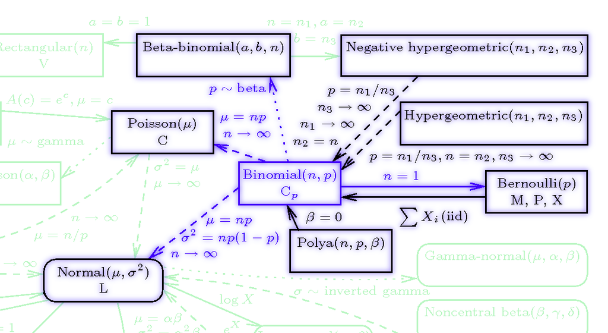